# Fitting an ERGM and Viewing the Output with tabulergm

## Overview

This vignette demonstrates how to:

1. Fit an ERGM using the **ergm** package.
2. Produce a publication-ready Markdown table with `tabulergm_table(format = "markdown")`.
3. Render the table inline in a Quarto or R Markdown document using `results: asis`.
4. Replace the shipped term titles, descriptions, and citations for a single table.
5. Interactively preview the table in the RStudio viewer (or a browser) with `tabulergm_view()`.

## Setup

```r
library(ergm)
library(tabulergm)
```

## Fitting the model

We use the Florentine marriage network, which ships with **ergm**, and fit a simple model with an `edges` term and a `nodematch` term for wealth quartile.

```r
data(florentine)

model <- ergm(
  flomarriage ~ edges + nodematch("wealth"),
  control = control.ergm(seed = 42)
)
summary(model)
```

```
#> Call:
#> ergm(formula = flomarriage ~ edges + nodematch("wealth"), control = control.ergm(seed = 42))
#>
#> Maximum Likelihood Results:
#>
#>                  Estimate Std. Error MCMC % z value Pr(>|z|)
#> edges             -1.5892     0.2454      0  -6.477   <1e-04 ***
#> nodematch.wealth     -Inf     0.0000      0    -Inf   <1e-04 ***
#> ---
#> Signif. codes:  0 '***' 0.001 '**' 0.01 '*' 0.05 '.' 0.1 ' ' 1
#>
#>      Null Deviance: 166.4  on 120  degrees of freedom
#>  Residual Deviance: 107.4  on 118  degrees of freedom
#>
#> AIC: 109.4  BIC: 112.2  (Smaller is better. MC Std. Err. = 0)
#> Warnings:
#>
#>  * The following terms have infinite coefficient estimates due to an
#>    extreme sufficient statistic:
#>
#>    nodematch.wealth
```

## Creating a Markdown table

Calling `tabulergm_table()` with `format = "markdown"` returns a `knitr_kable` object. Adding the chunk option `results: asis` (or `results = "asis"` in R Markdown) causes knitr to emit the table verbatim, so the Markdown renderer (Quarto, Pandoc, GitHub, etc.) formats it properly.

Math notation in the **math** column is automatically wrapped in `$...$` so that Pandoc can render it reliably in table cells across output formats, including Word. Network figures in the **figure** column are emitted with Markdown image syntax.

> **Quarto tip:** use `#| results: asis` (or `results = "asis"` in R Markdown) on the chunk so that knitr emits the table verbatim instead of quoting it.

```r
tabulergm_table(
  model,
  include_math        = TRUE,
  include_description = TRUE,
  format              = "markdown"
)
```

term

figure

estimate

se

pvalue

description

math

edges

-1.59

0.25

<0.01

Counts the ties present in the network. Acts as the baseline density term, playing the role an intercept plays in a regression model. (holland1981)

$\sum_{i<j} y_{ij}$

nodematch

-Inf

0.00

<0.01

Counts the ties joining nodes that share the same value of a categorical attribute, the standard measure of homophily. Setting diff = TRUE adds one statistic per attribute value (differential homophily). (wasserman1996; mcpherson2001)

$\sum_{i<j} y_{ij} \mathbf{1}(x_i = x_j)$

*Note: Orange nodes indicate nodes with a focal attribute.*

$$holland1981$$
[doi:10.1080/01621459.1981.10477598](https://doi.org/10.1080/01621459.1981.10477598)
$$wasserman1996$$
[doi:10.1007/BF02294547](https://doi.org/10.1007/BF02294547)
$$mcpherson2001$$
[doi:10.1146/annurev.soc.27.1.415](https://doi.org/10.1146/annurev.soc.27.1.415)

## Customizing titles, descriptions, and citations

Each term carries a short `title` and a plain-language `description`, taken from `tabulergm`’s term dictionary and falling back to the `ergm` term database for terms the dictionary does not cover. Add the `title` column with `include_title = TRUE`, and replace either field for a single table with the `override.*` arguments:

```r
tabulergm_table(
  model,
  include_title       = TRUE,
  include_description = TRUE,
  override.title      = c(edges = "Density"),
  override.desc       = c(edges = "Baseline propensity to form ties."),
  format              = "markdown"
)
```

term

title

figure

estimate

se

pvalue

description

edges

Density

-1.59

0.25

<0.01

Baseline propensity to form ties. (holland1981)

nodematch

Uniform homophily

-Inf

0.00

<0.01

Counts the ties joining nodes that share the same value of a categorical attribute, the standard measure of homophily. Setting diff = TRUE adds one statistic per attribute value (differential homophily). (wasserman1996; mcpherson2001)

*Note: Orange nodes indicate nodes with a focal attribute.*

$$holland1981$$
[doi:10.1080/01621459.1981.10477598](https://doi.org/10.1080/01621459.1981.10477598)
$$wasserman1996$$
[doi:10.1007/BF02294547](https://doi.org/10.1007/BF02294547)
$$mcpherson2001$$
[doi:10.1146/annurev.soc.27.1.415](https://doi.org/10.1146/annurev.soc.27.1.415)

`override.math`, `override.figure`, and `override.citation` work the same way, and the single `override` argument sets several fields at once:

```r
tabulergm_table(
  model,
  override = list(
    edges     = list(title = "Density", desc = "Baseline tie propensity."),
    nodematch = list(citation = "doi:10.1016/S0378-8733(01)00029-6")
  )
)
```

Override names are matched against the term name first and the coefficient name second, so an expanded coefficient such as `nodematch.wealth.3` can be targeted on its own.

Terms with a citation show a `(key)` marker next to their description, and the matching `[key] identifier` line is appended below the table. Citations are stored as a DOI, arXiv id, PubMed id, or URL rather than a formatted reference, so readers can import them into their own bibliography software:

```r
tabulergm_table(
  flomarriage ~ gwesp(0.5, fixed = TRUE) + gwdegree(0.5, fixed = TRUE),
  format = "markdown"
)
```

term

figure

math

description

gwesp

$\exp{(\tau)} \sum_{i=1}^{n-2} \left[1 - \left(1 - \exp{(-\tau)}\right)^i\right] EP_i(y)$

Summarizes how many partners tied nodes share, weighting each additional shared partner geometrically less than the last. Provides a better-behaved measure of transitive closure than a raw triangle count; the decay parameter controls how fast the weights fall off. (snijders2006; hunter2007)

gwdegree

$\exp{(\tau)} \sum_{i=1}^{n-1} \left[1 - \left(1 - \exp{(-\tau)}\right)^i\right] D_i(y)$

Summarizes the degree distribution with geometrically decreasing weights. Captures whether ties concentrate on a few high-degree nodes or spread evenly, and stabilizes models that would otherwise degenerate. (snijders2006; hunter2007)

$$snijders2006$$
[doi:10.1111/j.1467-9531.2006.00176.x](https://doi.org/10.1111/j.1467-9531.2006.00176.x)
$$hunter2007$$
[doi:10.1016/j.socnet.2006.08.005](https://doi.org/10.1016/j.socnet.2006.08.005)

## Reorganizing a table with styles

The default table uses one column per metadata component. For a compact dictionary-style layout, pipe a table through `with_style_name_over_formula()`. It places the curated title over the formula in a **Name** cell and puts the term drawing in **Representation**, while retaining model statistics and any columns explicitly requested from `tabulergm_table()`.

```r
tabulergm_table(
  flomarriage ~ edges + nodematch("wealth") + triangle,
  include_description = FALSE,
  format = "markdown"
) |>
  with_style_name_over_formula()
```

Name

Representation

Number of edges (holland1981)
$$\sum_{i\lt{}j} y_{ij}$$

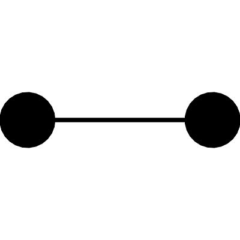

Uniform homophily (wasserman1996; mcpherson2001)
$$\sum_{i\lt{}j}
y_{ij} \mathbf{1}(x_i = x_j)$$

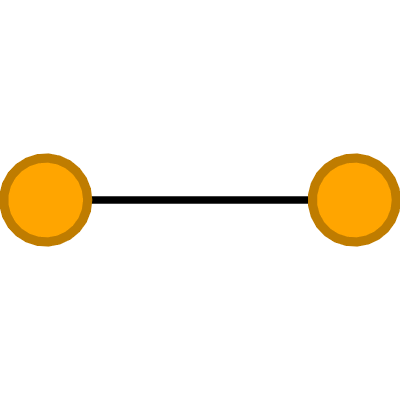

Triangles (frank1986)
$$\sum_{i\lt{}j\lt{}k} y_{ij} y_{jk}
y_{ik}$$

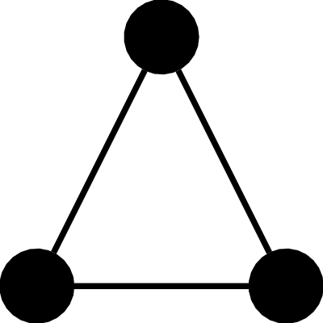

*Note: Orange nodes indicate nodes with a focal attribute.*

*[holland1981] [doi:10.1080/01621459.1981.10477598](https://doi.org/10.1080/01621459.1981.10477598)*  
*[wasserman1996] [doi:10.1007/BF02294547](https://doi.org/10.1007/BF02294547)*  
*[mcpherson2001] [doi:10.1146/annurev.soc.27.1.415](https://doi.org/10.1146/annurev.soc.27.1.415)*  
*[frank1986] [doi:10.1080/01621459.1986.10478342](https://doi.org/10.1080/01621459.1986.10478342)*

Styled Markdown is emitted as a raw HTML table because pipe tables cannot reliably hold the multi-line name/formula cells. This layout is therefore for HTML-capable Markdown targets; use the default plain style for portable pipe tables. `with_style_plain()` restores the original layout.

The same styled data frame can be saved or previewed through a pipe:

```r
tabulergm_table(model, include_description = FALSE) |>
  with_style_name_over_formula() |>
  tabulergm_save("compact-ergm")

tabulergm_table(model, include_description = FALSE) |>
  with_style_name_over_formula() |>
  tabulergm_view()
```

The compact LaTeX snippet requires the `array`, `booktabs`, and `graphicx` packages for multiline cells and figures. Fitted-model estimates, standard errors, and p-values display two decimal places by default; use `digits = NULL` to retain full precision or set another number of decimal places.

Compact-style presentation settings are carried by the table object, so the same layout is used for previews and saved output. `column_widths` takes named fractions of the table width and `figure_height` is measured in inches:

```r
tabulergm_table(model, include_description = FALSE) |>
  with_style_name_over_formula(
    column_widths = c(Name = .5, Representation = .2),
    figure_height = .8
  ) |>
  tabulergm_save("compact-ergm")
```

## Inspecting a formula without a fitted model

You can also pass a bare formula to inspect term metadata before fitting:

```r
tabulergm_table(
  flomarriage ~ edges + nodematch("wealth") + triangle,
  format = "markdown"
)
```

term

figure

math

description

edges

$\sum_{i<j} y_{ij}$

Counts the ties present in the network. Acts as the baseline density term, playing the role an intercept plays in a regression model. (holland1981)

nodematch

$\sum_{i<j} y_{ij} \mathbf{1}(x_i = x_j)$

Counts the ties joining nodes that share the same value of a categorical attribute, the standard measure of homophily. Setting diff = TRUE adds one statistic per attribute value (differential homophily). (wasserman1996; mcpherson2001)

triangle

$\sum_{i<j<k} y_{ij} y_{jk} y_{ik}$

Counts the sets of three mutually connected nodes, the basic measure of local clustering in an undirected network. (frank1986)

*Note: Orange nodes indicate nodes with a focal attribute.*

$$holland1981$$
[doi:10.1080/01621459.1981.10477598](https://doi.org/10.1080/01621459.1981.10477598)
$$wasserman1996$$
[doi:10.1007/BF02294547](https://doi.org/10.1007/BF02294547)
$$mcpherson2001$$
[doi:10.1146/annurev.soc.27.1.415](https://doi.org/10.1146/annurev.soc.27.1.415)
$$frank1986$$
[doi:10.1080/01621459.1986.10478342](https://doi.org/10.1080/01621459.1986.10478342)

## The term dictionary

`tabulergm` ships math and network drawings for commonly used ERGM terms, including directed variants and mode-specific bipartite terms (`b1*` terms summarize the first mode, and `b2*` terms summarize the second mode). The table below covers every term currently included in the dictionary; terms with both directed and undirected definitions (`edges`, `gwesp`, `gwdsp`, `isolates`) display the undirected version:

```r
dictionary_terms <- network ~
  edges + mutual + triangle +
  gwesp(0.5, fixed = TRUE) + gwdsp(0.5, fixed = TRUE) +
  gwdegree(0.5, fixed = TRUE) + altkstar(2, fixed = TRUE) +
  nodematch("attr") + nodefactor("attr") + nodemix("attr") +
  nodecov("attr") + absdiff("attr") + edgecov("cov") +
  transitiveties + cyclicalties +
  nodeicov("attr") + nodeocov("attr") +
  gwidegree(0.5, fixed = TRUE) + gwodegree(0.5, fixed = TRUE) +
  nodeifactor("attr") + nodeofactor("attr") +
  kstar(2) + istar(2) + ostar(2) +
  isolates + degree(1) + concurrent +
  dgwesp(0.5, fixed = TRUE) + dgwdsp(0.5, fixed = TRUE) +
  gwb1dsp(0.5, fixed = TRUE) + gwb2dsp(0.5, fixed = TRUE) +
  gwb1degree(0.5, fixed = TRUE) + gwb2degree(0.5, fixed = TRUE) +
  b1factor("type") + b2factor("group") +
  b1nodematch("type") + b2nodematch("group") +
  b1starmix(2, "type") + b2starmix(2, "group")

tabulergm_table(dictionary_terms, format = "markdown")
```

term

figure

math

description

edges

$\sum_{i<j} y_{ij}$

Counts the ties present in the network. Acts as the baseline density term, playing the role an intercept plays in a regression model. (holland1981)

mutual

$\sum_{i<j} y_{ij} y_{ji}$

Counts the dyads in which both directed ties are present, capturing the tendency for ties to be returned. (holland1981)

triangle

$\sum_{i<j<k} y_{ij} y_{jk} y_{ik}$

Counts the sets of three mutually connected nodes, the basic measure of local clustering in an undirected network. (frank1986)

gwesp

$\exp{(\tau)} \sum_{i=1}^{n-2} \left[1 - \left(1 - \exp{(-\tau)}\right)^i\right] EP_i(y)$

Summarizes how many partners tied nodes share, weighting each additional shared partner geometrically less than the last. Provides a better-behaved measure of transitive closure than a raw triangle count; the decay parameter controls how fast the weights fall off. (snijders2006; hunter2007)

gwdsp

$\exp{(\tau)} \sum_{i=1}^{n-2} \left[1 - \left(1 - \exp{(-\tau)}\right)^i\right] DP_i(y)$

Summarizes shared partners over every dyad, tied or not, with geometrically decreasing weights. Commonly paired with gwesp to separate shared partnership from closure itself. (snijders2006; hunter2007)

gwdegree

$\exp{(\tau)} \sum_{i=1}^{n-1} \left[1 - \left(1 - \exp{(-\tau)}\right)^i\right] D_i(y)$

Summarizes the degree distribution with geometrically decreasing weights. Captures whether ties concentrate on a few high-degree nodes or spread evenly, and stabilizes models that would otherwise degenerate. (snijders2006; hunter2007)

altkstar

$\sum_{k=2}^{n-1} (-1)^k \frac{S_k(y)}{\lambda^{k-2}}$

Alternating sum of the k-star counts, an equivalent parameterization of the geometrically weighted degree distribution used to model degree heterogeneity. (snijders2006; hunter2007)

nodematch

$\sum_{i<j} y_{ij} \mathbf{1}(x_i = x_j)$

Counts the ties joining nodes that share the same value of a categorical attribute, the standard measure of homophily. Setting diff = TRUE adds one statistic per attribute value (differential homophily). (wasserman1996; mcpherson2001)

nodefactor

$\sum_{i<j} y_{ij} \left[\mathbf{1}(x_i = k) + \mathbf{1}(x_j = k)\right]$

Counts the tie endpoints belonging to each level of a categorical attribute, measuring how active nodes with that value are in forming ties.

nodemix

$\sum_{i<j} y_{ij} \mathbf{1}(\{x_i, x_j\} = \{k, l\})$

Counts the ties for every pairing of attribute values, reproducing the full mixing matrix of a categorical attribute. (wasserman1996; morris1991)

nodecov

$\sum_{i<j} y_{ij} (x_i + x_j)$

Sums a quantitative attribute over both ends of each tie, measuring how strongly that attribute drives tie formation.

absdiff

$\sum_{i<j} y_{ij} \left\lvert{}x_i - x_j\right\rvert{}$

Sums the absolute difference in a quantitative attribute across tied nodes. Negative estimates indicate homophily, since similar nodes contribute less.

edgecov

$\sum_{i<j} y_{ij} x_{ij}$

Sums a fixed dyad-level covariate over the observed ties, letting an external matrix such as distance or a previously observed network predict tie formation. (wasserman1996)

transitiveties

$\sum_{i \neq j} y_{ij} \mathbf{1}\left(\exists k : y_{ik} y_{kj} = 1\right)$

Counts the ties closed by at least one two-path. Unlike a triple count, a tie contributes once no matter how many shared partners it has.

cyclicalties

$\sum_{i \neq j} y_{ij} \mathbf{1}\left(\exists k : y_{jk} y_{ki} = 1\right)$

Counts the ties that take part in at least one cycle, capturing generalized exchange rather than hierarchy.

nodeicov

$\sum_{i \neq j} y_{ij} x_j$

Sums the receiving node’s attribute value over all ties, measuring how a quantitative attribute drives incoming ties (popularity).

nodeocov

$\sum_{i \neq j} y_{ij} x_i$

Sums the sending node’s attribute value over all ties, measuring how a quantitative attribute drives outgoing ties (activity).

gwidegree

$\exp{(\tau)} \sum_{i=1}^{n-1} \left[1 - \left(1 - \exp{(-\tau)}\right)^i\right] D^{\mathrm{in}}_i(y)$

Summarizes the in-degree distribution with geometrically decreasing weights. Captures whether incoming ties concentrate on a few popular nodes or spread evenly across receivers. (hunter2007; robins2009)

gwodegree

$\exp{(\tau)} \sum_{i=1}^{n-1} \left[1 - \left(1 - \exp{(-\tau)}\right)^i\right] D^{\mathrm{out}}_i(y)$

Summarizes the out-degree distribution with geometrically decreasing weights. Captures whether outgoing ties concentrate on a few highly active nodes or spread evenly across senders. (hunter2007; robins2009)

nodeifactor

$\sum_{i \neq j} y_{ij} \mathbf{1}(x_j = k)$

Counts the incoming ties received by nodes at each level of a categorical attribute, measuring how popular nodes with that value are as receivers.

nodeofactor

$\sum_{i \neq j} y_{ij} \mathbf{1}(x_i = k)$

Counts the outgoing ties sent by nodes at each level of a categorical attribute, measuring how active nodes with that value are as senders.

kstar

$\sum_{i} \binom{\sum_{j \neq i} y_{ij}}{k}$

Counts the sets of k ties that share a common node, a Markov dependence measure of degree heterogeneity. Pass several values of k to include one statistic per star size. (frank1986)

istar

$\sum_{j} \binom{\sum_{i \neq j} y_{ij}}{k}$

Counts the sets of k incoming ties that share a common receiver, capturing the spread of in-degrees (popularity). Pass several values of k to include one statistic per star size. (wasserman1996)

ostar

$\sum_{i} \binom{\sum_{j \neq i} y_{ij}}{k}$

Counts the sets of k outgoing ties that share a common sender, capturing the spread of out-degrees (activity). Pass several values of k to include one statistic per star size. (wasserman1996)

isolates

$\sum_{i} \mathbf{1}\left(\sum_{j \neq i} y_{ij} = 0\right)$

Counts the nodes with no ties, capturing an excess (or shortage) of isolated nodes relative to the rest of the degree distribution.

degree

$\sum_{i} \mathbf{1}\left(\sum_{j \neq i} y_{ij} = d\right)$

Counts the nodes with exactly d ties. Pass several values of d to include one statistic per degree, e.g. to model low-degree nodes explicitly.

concurrent

$\sum_{i} \mathbf{1}\left(\sum_{j \neq i} y_{ij} \geq 2\right)$

Counts the nodes with two or more ties, the number of actors holding concurrent partnerships. Common in models of sexual networks and disease transmission.

dgwesp

$\exp{(\tau)} \sum_{i=1}^{n-2} \left[1 - \left(1 - \exp{(-\tau)}\right)^i\right] EP^{\mathrm{OTP}}_i(y)$

Directed counterpart of the edgewise shared partner statistic, measuring transitive closure with geometrically decreasing weights. Outgoing two-paths are counted by default; the term’s type argument selects a different two-path orientation. (hunter2007; robins2009)

dgwdsp

$\exp{(\tau)} \sum_{i=1}^{n-2} \left[1 - \left(1 - \exp{(-\tau)}\right)^i\right] DP^{\mathrm{OTP}}_i(y)$

Directed counterpart of the dyadwise shared partner statistic, computed over every ordered dyad. Outgoing two-paths are counted by default; the term’s type argument selects a different two-path orientation. (hunter2007; robins2009)

gwb1dsp

$\exp{(\tau)} \sum_{i=1}^{n_{B_2}} \left[1 - \left(1 - \exp{(-\tau)}\right)^i\right] DP_i(y)$

Summarizes how many second-mode nodes each pair of first-mode nodes has in common, weighting additional shared partners geometrically less. (wang2009; hunter2007)

gwb2dsp

$\exp{(\tau)} \sum_{i=1}^{n_{B_1}} \left[1 - \left(1 - \exp{(-\tau)}\right)^i\right] DP_i(y)$

Summarizes how many first-mode nodes each pair of second-mode nodes has in common, weighting additional shared partners geometrically less. (wang2009; hunter2007)

gwb1degree

$\exp{(\tau)} \sum_{i=1}^{n_{B_2}} \left[1 - \left(1 - \exp{(-\tau)}\right)^i\right] D^{B_1}_i(y)$

Summarizes the degree distribution of first-mode nodes with geometrically decreasing weights. Captures whether ties to the second mode concentrate on a few highly active first-mode nodes or spread evenly across them. (wang2009; hunter2007)

gwb2degree

$\exp{(\tau)} \sum_{i=1}^{n_{B_1}} \left[1 - \left(1 - \exp{(-\tau)}\right)^i\right] D^{B_2}_i(y)$

Summarizes the degree distribution of second-mode nodes with geometrically decreasing weights. Captures whether ties from the first mode concentrate on a few popular second-mode nodes or spread evenly across them. (wang2009; hunter2007)

b1factor

$\sum_{i \in B_1} \sum_{j \in B_2} y_{ij} \mathbf{1}(x_i = k)$

Counts the ties incident on first-mode nodes at each level of a categorical attribute, measuring how active those nodes are.

b2factor

$\sum_{i \in B_1} \sum_{j \in B_2} y_{ij} \mathbf{1}(x_j = k)$

Counts the ties incident on second-mode nodes at each level of a categorical attribute, measuring how active those nodes are.

b1nodematch

$\sum_{k\in B_2} \sum_{i<j \in B_1} \mathbf{1}(x_i = x_j) y_{ik} y_{jk}$

Counts the pairs of first-mode nodes that share an attribute value and are both tied to the same second-mode node. The alpha and beta discount parameters temper the count when nodes share many partners. (bomiriya2023)

b2nodematch

$\sum_{k\in B_1} \sum_{i<j \in B_2} \mathbf{1}(x_i = x_j) y_{ik} y_{jk}$

Counts the pairs of second-mode nodes that share an attribute value and are both tied to the same first-mode node. The alpha and beta discount parameters temper the count when nodes share many partners. (bomiriya2023)

b1starmix

$\sum_{i \in B_1} \mathbf{1}(x_i = p) \sum_{j_1 < \cdots < j_k \in B_2} \prod_{l=1}^{k} y_{i j_l} \mathbf{1}(x_{j_l} = q)$

Counts the k-stars centered on a first-mode node with one attribute value whose second-mode neighbors all share another, capturing mixing and degree together.

b2starmix

$\sum_{j \in B_2} \mathbf{1}(x_j = p) \sum_{i_1 < \cdots < i_k \in B_1} \prod_{l=1}^{k} y_{i_l j} \mathbf{1}(x_{i_l} = q)$

Counts the k-stars centered on a second-mode node with one attribute value whose first-mode neighbors all share another, capturing mixing and degree together.

*Note: Orange nodes indicate nodes with a focal attribute. Orange and teal nodes represent nodes with different values of the focal attribute. Square nodes represent nodes in the first mode and circle nodes in the second mode.*

$$holland1981$$
[doi:10.1080/01621459.1981.10477598](https://doi.org/10.1080/01621459.1981.10477598)
$$frank1986$$
[doi:10.1080/01621459.1986.10478342](https://doi.org/10.1080/01621459.1986.10478342)
$$snijders2006$$
[doi:10.1111/j.1467-9531.2006.00176.x](https://doi.org/10.1111/j.1467-9531.2006.00176.x)
$$hunter2007$$
[doi:10.1016/j.socnet.2006.08.005](https://doi.org/10.1016/j.socnet.2006.08.005)
$$wasserman1996$$
[doi:10.1007/BF02294547](https://doi.org/10.1007/BF02294547)
$$mcpherson2001$$
[doi:10.1146/annurev.soc.27.1.415](https://doi.org/10.1146/annurev.soc.27.1.415)
$$morris1991$$
doi:10.1016/0025-5564(91)90014-A
$$robins2009$$
[doi:10.1016/j.socnet.2008.10.006](https://doi.org/10.1016/j.socnet.2008.10.006)
$$wang2009$$
[doi:10.1016/j.socnet.2008.08.002](https://doi.org/10.1016/j.socnet.2008.08.002)
$$bomiriya2023$$
[arXiv:2312.05673](https://arxiv.org/abs/2312.05673)

## Interactive preview with `tabulergm_view()`

During an interactive session you can call `tabulergm_view()` to open the table in the RStudio viewer pane or the system browser:

```r
tabulergm_view(model, include_math = TRUE, include_description = TRUE)
```

`tabulergm_view()` builds a self-contained HTML page that loads MathJax from a CDN, so LaTeX math and embedded network figures render immediately without any additional setup.